# Coursework Report

*N* removed NAs: 2

*N* removed typo: 1

*N* removed <18: 38

*N* total clean: 109

| Group | *N* | *M*<sub>age</sub> | *M*<sub>rating</sub> |
| --- | --- | --- | --- |
| Control | 55 | 20.6 | 6.40 |
| Experim | 54 | 20.6 | 5.67 |

**Main analysis results**

*t*(107) = 4.39, *p* < .001

[interactive chart not shown]

[figure not shown]

[interactive chart not shown]

# Coursework Report

Analysing Data, Spring 2020

# Methods

## Participants

For this experiment data from 150 participants was collected. As their age was not specified 3 participants were removed and 38 participants were removed as their age given was 17 years old or below. This ensures that data from minors is not used, leaving the final number of participants as 109. This includes 55 in the control condition and 54 in the experimental condition (see Table 1). The minimum age of participant is 18 years old and the maximum is 26 years old. The mean and standard deviation of participants ages grouped by experimental condition is shown in below in Table 1.

Table 1 *Descriptive statistics by Experimental Condition*

| Condition | *N* | % | *M*<sub>age</sub> | *SD*<sub>age</sub> |
| --- | --- | --- | --- | --- |
| control | 55 | 50.5 | 20.6 | 2.16 |
| experimental | 54 | 49.5 | 20.6 | 2.10 |

## Design

This experiment is designed to study whether the colour red increases womens pereived attractiveness of men without their awareness. We looked at whether presenting a picture of a man with a red background would increase the ratings of attraction from the participants compared to those viewing the picture with a white background. Colour is the independent categorical variable, with red used in the experimental condition and white in the control conditon. Perceived attractiveness is the continuous dependent variable and is measured on a scale of 1 to 9. A high score of 9 is to be interpreted as very attractive and a low score of 1 is to be interpreted as not attractive. After the participant views the picture of the man for 5 seconds, they are asked ‘How attractive do you think this person is?’, ‘How pleasant is this person to look at?’ and ‘If I were to meet the person in this picture face to face, I would I think he is attractive.’ The participant responds to each question and a mean rating of attractiveness is calculated across the three questions.

# Results

The purpose of this study was to examine whether the colour red increases womens’ attractiveness towards men without their awareness. The scores given from each participant across the three questions were averaged to given an overall composite score. The composite scores in each condition were averaged to create two comparable means, which created a mean score of 6.40 for the control group and a mean score of 5.67 for the experimental group(see Graph 1 below), revealing that those in the control condition scored the men on average higher than those in the experimental condition. An independent t-test was conducted to explore whether colour influenced womens’ perceived attractiveness of men and found that there was a significant difference between the mean scores of attractiveness for the control and experimental groups (*M*<sub>diff</sub> = 0.73, 95% CI [0.4, 1.06], *t* (107) = 4.39, *p* `<0.001`).

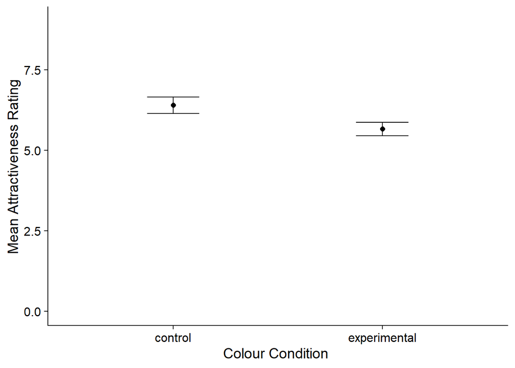

# Discussion

This study does not provide evidence for the hypothesis that the colour red increases womens’ perceived attraction towards men. This hypothesis was tested using pcitures of men against a white background in the control condition and a red background in the experimental condition to measure the effects of colour on perceived attractiveness upon first impression. The results show that the mean response in the control condition was significantly higher than the mean response for the experimental condition, so the null hypothesis was rejected. This means that the colour white in this study is associated with higher pereceived attraction compared to the colour red.

These findings do not replicate those of the study we intended to replicate (Elliot et al., 2010). This past research found evidence to support their hypothesis that the colour red increases women’s perceived attraction towards men. Perhaps the reason why our study provides conflicting evidence to the study we set out to replicate is because there is publication bias in the origional study(Francis, 2012). This had been argued due to it not being likely that all five experiments conducted reject the null hypothesis. This means that there may have been results of the colour red not having a significant influence on perceived attractiveness however these findings were not published. This can certainly be true as later research was published to replicate the origional study after claims of a publication bias and found no significant effect for the influence of red on perceived attractiveness(Elliot & Maier, 2013). This means that our results are not as uncommon as initially thought. Another study that intended to replicate this research also found that red had no significant effect on perceived attractiveness(Hesslinger et al., 2015). In this study they found that a formal apparel style compared to a casual apparel style increased perceived attractiveness(Hesslinger et al., 2015). This suggests that style is more important in influencing attraction compared to colour. It could be that our study reported no significant effect for red because there was an alternative factor in our study that increased perceived attractiveness for those in the control condition.

This links in to the limitations of this study. Firstly, we only presented one man to each participant. This limits our findings as we are unable to see whether there is an alternative factor, such as style or distinctive facial features, that increase perceived attractiveness. As mentioned previously, research has shown how style is more influential that colour in relation to increasing preceived attractiveness(Hesslinger et al., 2015). The use of one picture also limits our findings as we are unable to see the effect of colour on pictures of men that differ in age and race, for example, on perceived attractivness. This is also relevant to our study as the picture chosen was of a moderately attractive man, therefore if a wider variety of pictures were used we would be able to see if there is a relationship between certain features and higher attractive ratings. Moreover, this study only presented the picture of the man for five seconds and so attractiveness ratings were only based on first impressions. This means we are unable to see if the ratings of attractiveness would differ if the pictures were viewed for longer. Previous research(Peperkoorn et al., 2016) has looked at this and allowed the participant to view the picture for as long as felt necessary, and found no relationship between the colour red and attractiveness. This highlights how more research is needed to further examine whether this effect of red is real and if it only applies in certain situations. In addition, the age of participants ranged from 18 years old to 26 years old. This is a narrow age range meaning we only looked at he extent to which young adults perceive a man to be attractive. This limits our findings as we are unable to see whether the colour red influences perceived attractiveness across different age categories. This reinforces the idea that further studies are needed to provide clarity on whether colour influences perceived attractiveness.

Future research should use larger samples of participants to examine whether colour influences attractiveness ratings. Previous studies have used larger sample sizes and found that red does not influence attractiveness(Hesslinger et al., 2015; Peperkoorn et al., 2016). This suggests that this effect found in the origional study was limited to the smaller sample and not a true reflection on whether colour increases perceived attraction. This relates to the idea that future studies could go beyond using a picture to using face-to-face studies to examine whether red influences attraction. The person could be stood infront of a coloured wall or be wearing an item of red clothing. This will be interesting to see how the particpants rate the attractiveness of the men to see whether the effect of colour is just limited to photos or whether it can be also seen with person-to-person contact. Furthermore, in this study and other previous research white was found to have a significant effect on ratings of attractiveness compared to red(Hesslinger et al., 2015; Peperkoorn et al., 2016). The effect of the colour white should be researched further to see if it is linked with purity or faithfulness which is perhaps then the reason for it influencing perceived attractiveness. Previous research has looked at whether white is linked to faithfulness however no relationship was found(Peperkoorn et al., 2016). This indicates the need for further research to gain further understanding on whether colour influences perceptions and if so why.

Therefore, this study aimed to investigate whether the colour red increases women’s attractiveness towards men without their awareness. We focused on the participants first impressions of the men against either a red or white background. A series of three questions were then asked which involved the participants rating the men depending on how attractive they found them. We found that there was a significant difference in the means between the red and white conditions and the participants rated the men more attractive in conjunction with the colour white. The main limitations of this study was the narrow age range of participants used, the small sample size used and the use of only one picture of a male that a participant was asked to rate. This highlights how future research is needed for this research question to examine further whether colour influences perceived attractiveness. This should be done with larger sample sizes, with more research on the effects of white, and the use of presenting a person face-to-face rather than in a picture.

# References

Elliot, A. J., & Maier, M. A. (2013). The red-attractiveness effect, applying the Ioannidis and Trikalinos (2007b) test, and the broader scientific context: A reply to Francis (2013). Journal of Experimental Psychology. General, 142(1), 297–300. https://doi.org/10.1037/a0029592

Elliot, A. J., Niesta Kayser, D., Greitemeyer, T., Lichtenfeld, S., Gramzow, R. H., Maier, M. A., & Liu, H. (2010). Red, rank, and romance in women viewing men. Journal of Experimental Psychology: General, 139(3), 399–417. https://doi.org/10.1037/a0019689

Francis, G. (2012). Publication bias and the failure of replication in experimental psychology. Psychonomic Bulletin & Review, 19(6), 975–991. https://doi.org/10.3758/s13423-012-0322-y

Hesslinger, V. M., Goldbach, L., & Carbon, C.-C. (2015). Men in red: A reexamination of the red-attractiveness effect. Psychonomic Bulletin & Review, 22(4), 1142–1148. https://doi.org/10.3758/s13423-015-0866-8